# Week 8 Homework

Author: Laura Wooten

Last update: 27 May, 2025

**–Download data, check normalization–**

```r
library(GEOquery)
geodata <- getGEO("GSE10072", GSEMatrix = TRUE)
eset <- geodata[[1]]
eData <- exprs(eset)
pheno <- pData(eset)

save(eData, file = "GSE10072eData.Rda")
save(pheno, file = "GSE10072pData.Rda")
```

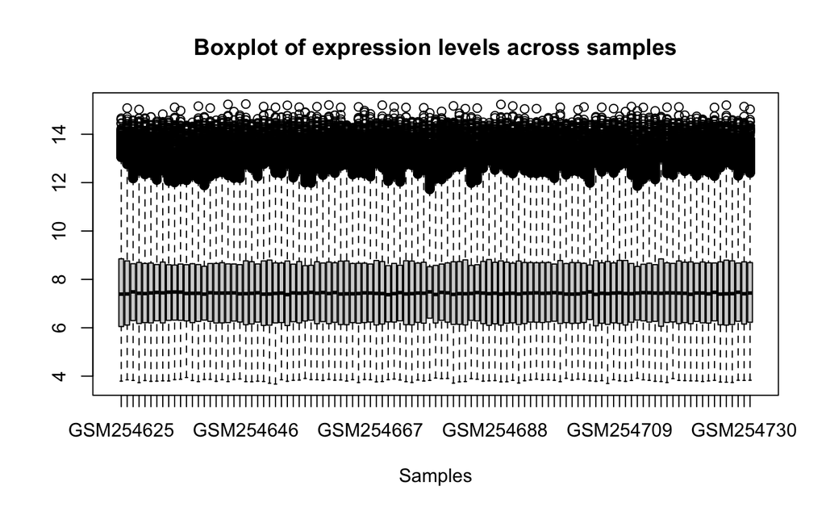

```r
#boxplot to determine if expression data is normalized
boxplot(eData, main= "Boxplot of expression levels across samples", xlab="Samples")
```

```r
#medians and IQRs all similar - normalization confirmed
```

The Boxplot of expression data across samples shows that the medians and IQRs fo expression values are very similar. This indicates that the data is well normalized and that there are no major differences in variation between samples.

# 1 Question 1.

Partition data to disease outcome - Tumor / Normal  
Categorical variable - Smoker / Never Smoker

```r
#Partition data: disease status (tumor/non tumor) and variable (current smoker and never smoker only [leave out former smoker])
smk_and_nonsk <- pheno$source_name_ch1=="Adenocarcinoma of the Lung" & (pheno$`Cigarette Smoking Status:ch1`=="Never Smoked" | pheno$`Cigarette Smoking Status:ch1`=="Current Smoker")
pheno_sns <- pheno[smk_and_nonsk,]
eData_sns <- eData[,smk_and_nonsk]
```

Categorical variable is smoking status = Current / Never  
Continuous variable is gene expression use eData (table of expression data genes are rows, samples are columns)

```r
#logistic regression - change smoking status to factor with two levels.
status <- as.factor(pheno_sns$`Cigarette Smoking Status:ch1`)

#initialize variables to store p-values and gene names
pvals <- numeric()
gene_names <- rownames(eData_sns)

#loop through every gene, run glm(status~gene), save pvalue
for (i in 1:nrow(eData_sns)){
  gene.i <- eData_sns[i,] #select i-th row all samples
  log.model <- glm(status~gene.i, family = binomial)
  #save pvalue (2nd row is gene variable)
  pvals[i] <- summary(log.model)$coefficients[2,"Pr(>|z|)"]
}

#create df to sort & plot
status.pvals <- data.frame(gene= gene_names, pval= pvals)
status.pvals.sorted <- status.pvals[order(status.pvals$pval),]
#print 5 most significant
status.pvals.sorted[1:5,]
```

|  | gene | pval |
| --- | --- | --- |
| 19151 | 219787_s_at | 0.0005815214 |
| 3087 | 203560_at | 0.0006515818 |
| 11406 | 212020_s_at | 0.0007270667 |
| 819 | 201291_s_at | 0.0008219696 |
| 9131 | 209642_at | 0.0008837083 |

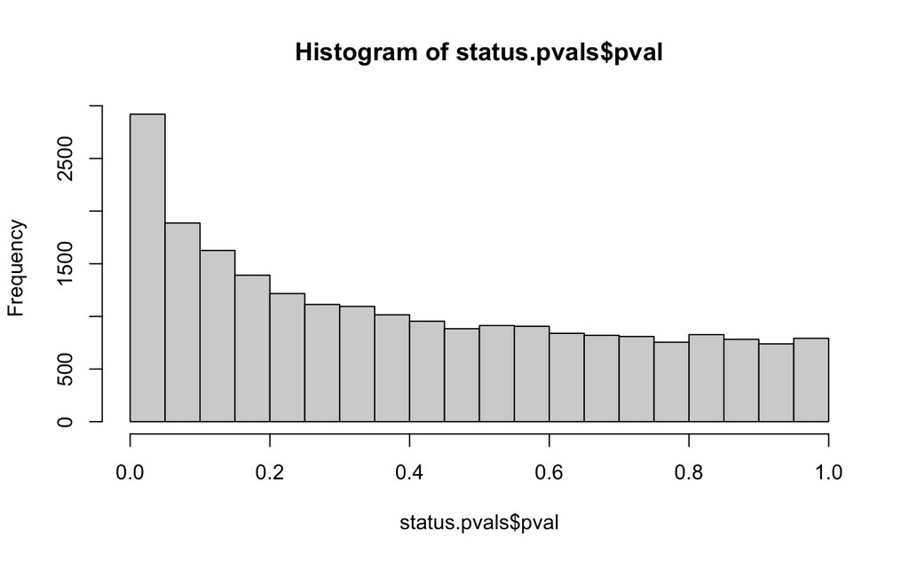

```r
#histogram of pvals
hist(status.pvals$pval)
```

**Leave-n-out:**

**Normalized Data**

```r
# I originally had this a loop but after performing on un-normalized data also, I was creating too many variables/objects to keep track of. Converted to a function.

leave_n_out_sampling <- function(exprs_data, status, gene_names, n.reps = 100, seed = 123) {
  set.seed(seed) # for reproducibility

  n.genes <- nrow(exprs_data)
  n.samples <- ncol(exprs_data)

  # Store mean and variance of p-values for each gene
  pval_means <- numeric(n.genes)
  pval_vars <- numeric(n.genes)

  for (i in 1:n.genes) {
    gene.i <- exprs_data[i,]
    pvals_cv <- replicate(n.reps, {
      leave_out <- sample(1:n.samples, 1)
      gene_train <- gene.i[-leave_out]
      status_train <- status[-leave_out]
      log.model <- glm(status_train ~ gene_train, family = binomial)
      summary(log.model)$coefficients[2, "Pr(>|z|)"]
    })
    pval_means[i] <- mean(pvals_cv, na.rm=TRUE)
    pval_vars[i] <- var(pvals_cv, na.rm=TRUE)
  }

  # Create data frame for results
  results_df <- data.frame(
    gene = gene_names,
    mean_pval = pval_means,
    var_pval = pval_vars
  )

  return(results_df)
}
```

```r
#Function call on normalized data (lets see how long it takes to run)
system.time({
  smpl.pvals.norm <- leave_n_out_sampling(eData_sns, status, gene_names)
})

save(smpl.pvals.norm, file = "status_resampling_norm.Rda")
```

```r
#sort df by most significant p-value, print top 5.
smpl.pvals.norm[order(smpl.pvals.norm$mean_pval), ][1:5,]
```

|  | gene | mean_pval | var_pval |
| --- | --- | --- | --- |
| 19151 | 219787_s_at | 0.0006992184 | 5.084579e-09 |
| 3087 | 203560_at | 0.0007764108 | 2.235040e-08 |
| 11406 | 212020_s_at | 0.0008720818 | 6.473863e-09 |
| 819 | 201291_s_at | 0.0009940132 | 2.087916e-08 |
| 9131 | 209642_at | 0.0010586514 | 1.203515e-08 |

**Describe**  
The leave-n-out resampling is assessing the stability of the logistic regression model and the association between gene expression and smoking status. The same top five genes appear, though with slightly higher mean p-values, suggesting that these associations are consistent across different subsets of the data and are not just artifacts of the specific sample in the first analysis. The low variance in p-values across iterations further supports that these gene expression differences are reliable and not heavily influenced by outliers.

By leaving out individual samples in replicates and recalculating p-values, this method accounts for the potential influence of any single sample disproportionately skewing the results. The fact that the mean p-values remain similar while the variance is minimal strengthens the reliability of these findings, reinforcing that these gene associations with smoking status are stable across resampling iterations.

Data was previously normalized - to artificially “de-normalize” add a constant value to eData. This does not account for batch effects - perform second “de-normalization” where constant is added to first half (to simulate batch effects).

**“De-normalize” #1: Shift scale by adding constant to all samples**  
**“De-normalize” #2: Mimic batch effects by adding constant to 1/2 of samples**

```r
#all samples
eData_sns_denorm1 <- eData_sns + 5
#First half of samples
eData_sns_denorm2 <- eData_sns
eData_sns_denorm2[, 1:floor(ncol(eData_sns)/2)] <- eData_sns_denorm2[, 1:floor(ncol(eData_sns)/2)] + 5

#plot to see differences with original data
oldpar <- par(mfrow = c(1, 3))
boxplot(eData_sns, main="normalized")
boxplot(eData_sns_denorm1, main="denorm with constant")
```

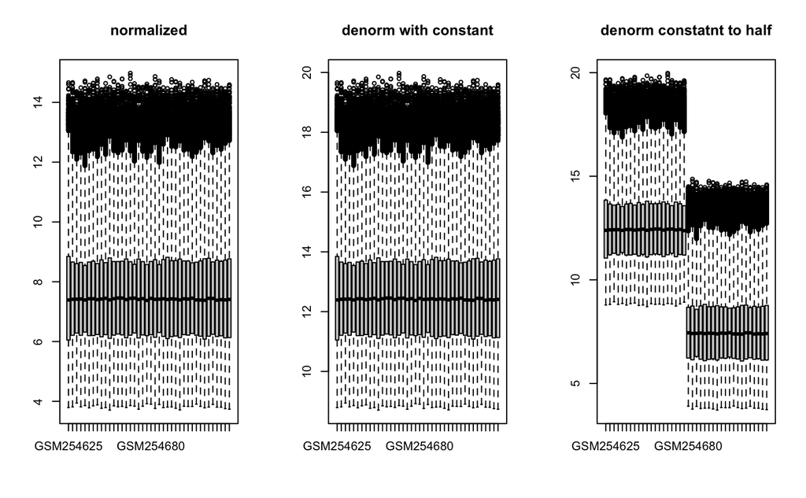

```r
boxplot(eData_sns_denorm2, main="denorm constatnt to half")
par(oldpar)
```

```r
# Repeat sampling for de-normalized data
smpl.pvals.denorm1 <- leave_n_out_sampling(eData_sns_denorm1, status, gene_names)
save(smpl.pvals.denorm1, file = "status_resampling_denorm1.Rda")

smpl.pvals.denorm2 <- leave_n_out_sampling(eData_sns_denorm2, status, gene_names)
save(smpl.pvals.denorm2, file = "status_resampling_denorm2.Rda")
```

```r
#######Comparisons of norm/denorm pvalues#######
# Show top 5 genes by mean p-value of each resampling df
print("Normalized leave-n-out resampling:")
```

```
[1] "Normalized leave-n-out resampling:"
```

```r
smpl.pvals.norm[order(smpl.pvals.norm$mean_pval), ][1:5,]
```

|  | gene | mean_pval | var_pval |
| --- | --- | --- | --- |
| 19151 | 219787_s_at | 0.0006992184 | 5.084579e-09 |
| 3087 | 203560_at | 0.0007764108 | 2.235040e-08 |
| 11406 | 212020_s_at | 0.0008720818 | 6.473863e-09 |
| 819 | 201291_s_at | 0.0009940132 | 2.087916e-08 |
| 9131 | 209642_at | 0.0010586514 | 1.203515e-08 |

```r
print("Synthetic de-normalized (+5 to all samples) leave-n-out resampling:")
```

```
[1] "Synthetic de-normalized (+5 to all samples) leave-n-out resampling:"
```

```r
smpl.pvals.denorm1[order(smpl.pvals.denorm1$mean_pval), ][1:5,]
```

|  | gene | mean_pval | var_pval |
| --- | --- | --- | --- |
| 19151 | 219787_s_at | 0.0006992184 | 5.084579e-09 |
| 3087 | 203560_at | 0.0007764108 | 2.235040e-08 |
| 11406 | 212020_s_at | 0.0008720818 | 6.473863e-09 |
| 819 | 201291_s_at | 0.0009940132 | 2.087916e-08 |
| 9131 | 209642_at | 0.0010586514 | 1.203515e-08 |

```r
print("Synthetic de-normalized (+5 to half of samples) leave-n-out resampling:")
```

```
[1] "Synthetic de-normalized (+5 to half of samples) leave-n-out resampling:"
```

```r
smpl.pvals.denorm2[order(smpl.pvals.denorm2$mean_pval), ][1:5,]
```

|  | gene | mean_pval | var_pval |
| --- | --- | --- | --- |
| 1437 | 201909_at | 0.06735753 | 0.0004026029 |
| 819 | 201291_s_at | 0.07257455 | 0.0004124172 |
| 21088 | 221728_x_at | 0.07836517 | 0.0004058864 |
| 3087 | 203560_at | 0.08191624 | 0.0005644327 |
| 4349 | 204822_at | 0.09182442 | 0.0006280353 |

```r
NA
```

```r
#Histogram
oldpar <- par(mfrow = c(3, 2))
hist(smpl.pvals.norm$mean_pval, breaks = 50, col = "blue",
     main = "Normalized Mean p-val", xlab = "mean pval/gene")
hist(smpl.pvals.norm$var_pval, breaks = 50, col = "blue",
     main = "Normalized p-val Variance", xlab = "p-val var/gene")
```

```r
hist(smpl.pvals.denorm1$mean_pval, breaks = 50, col = "red",
     main = "De-normalized (whole) Mean p-val", xlab = "Mean pval/gene")
hist(smpl.pvals.denorm1$var_pval, breaks = 50, col = "red",
     main = "De-normalized (whole) p-val Variance", xlab = "p-val var/gene")
```

```r
hist(smpl.pvals.denorm2$mean_pval, breaks = 50, col = "green",
     main = "De-normalized (half) Mean p-val", xlab = "Mean pval/gene")
hist(smpl.pvals.denorm2$var_pval, breaks = 50, col = "green",
     main = "De-normalized (half) p-val Variance", xlab = "p-val var/gene")
```

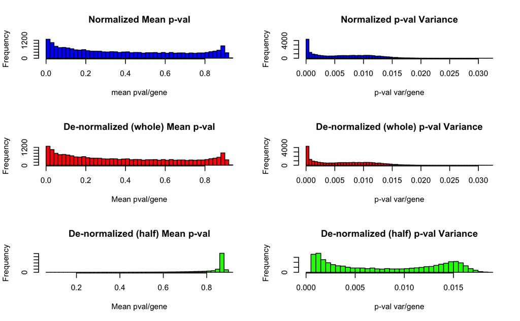

```r
par(oldpar)

#boxplots
oldpar <- par(mfrow = c(1, 2))
```

```r
boxplot(
  smpl.pvals.norm$mean_pval,
  smpl.pvals.denorm1$mean_pval,
  smpl.pvals.denorm2$mean_pval,
  main = "mean p-vals",
  col = c("blue", "red", "green"),
  names = c("Normalized", "De-norm (all)", "De-norm (half)"), cex.axis = 0.6)
boxplot(
  smpl.pvals.norm$var_pval,
  smpl.pvals.denorm1$var_pval,
  smpl.pvals.denorm2$var_pval,
  main = "var p-vals",
  col = c("blue", "red", "green"),
  names = c("Normalized", "De-norm (all)", "De-norm (half)"), cex.axis = 0.6)
```

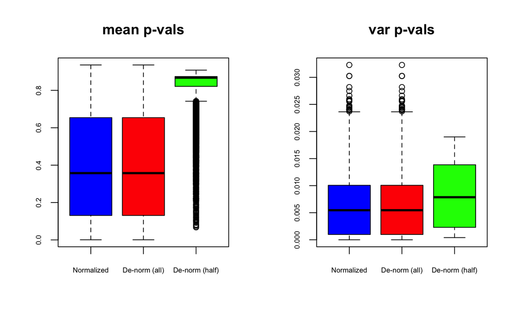

```r
par(oldpar)

#plot means and variances between norm/denorm data
oldpar <- par(mfrow = c(2, 2))
```

```r
plot(
  smpl.pvals.norm$mean_pval, smpl.pvals.denorm1$mean_pval,
  xlab = "Mean p-values(normalized)",
  ylab = "Mean p-values(de-normalized)",
  pch = 16, col = "blue"
)
abline(0, 1, col = "red", lwd = 2) # diagonal line for reference
```

```r
plot(
  smpl.pvals.norm$var_pval, smpl.pvals.denorm1$var_pval,
  xlab = "Variance of p-values(Normalized)",
  ylab = "Variance of p-value (de-normalized)",
  pch = 16, col = "blue"
)
abline(0, 1, col = "red", lwd = 2)
```

```r
plot(
  smpl.pvals.norm$mean_pval, smpl.pvals.denorm2$mean_pval,
  xlab = "Mean p-values(normalized)",
  ylab = "Mean p-values(half de-normalized)",
  pch = 16, col = "blue"
)
abline(0, 1, col = "red", lwd = 2) # diagonal line for reference
```

```r
plot(
  smpl.pvals.norm$var_pval, smpl.pvals.denorm2$var_pval,
  xlab = "Variance of p-values(Normalized)",
  ylab = "Variance of p-value (half de-normalized)",
  pch = 16, col = "blue"
)
abline(0, 1, col = "red", lwd = 2)
```

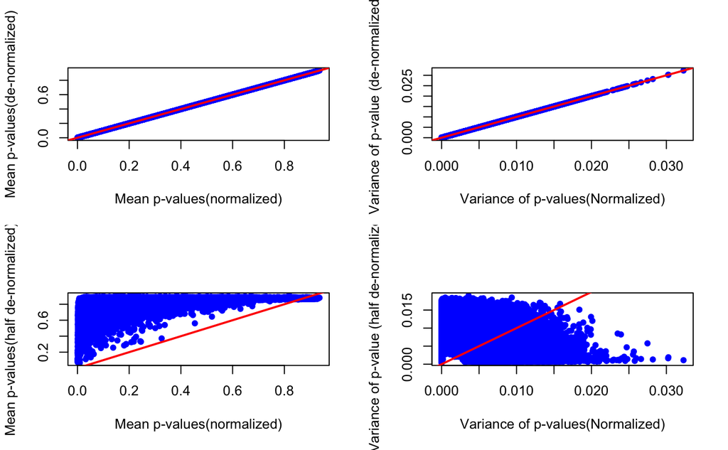

```r
par(oldpar)
```

**DISCUSS**  
Adding a constant to all samples does not change the differences between them, which makes sense because logistic regression isn’t affected by simply shifting values. This is because logistic regression models the link between gene expression and smoking status and depends on the relative differences/odds ratio, therefore adding a constant to all predictor values does not impact the model fit or the p-value. This is shown in the histograms, boxplots, and scatterplots as the distributions and relationships of mean and variance of p-values for normalized and de-normalized (all samples) data look identical, with points falling right on the diagonal in the scatterplots. This confirms that basic adjustments like this don’t interfere with detecting associations.

However, when introducing batch effects by shifting only half the samples, we can see a clear change where genes that were previously significant no longer are, and new genes appear with weaker associations. The histograms and boxplots show that mean p-values shift dramatically higher and variances increase, which indicates a loss of significant associations and greater instability in the results. The scatterplots also illustrate this, with points deviating far from the diagonal, reflecting the breakdown of correspondence between normalized and batch-effect data. This highlights how batch effects can mask real biological signals and introduce misleading patterns. Even though this was a dramatic example, it shows the importance of correcting for technical variance to ensure results truly reflect biological differences rather than artifacts from data processing.

# 2 Question 2.

From the link provided, I chose the Primary Biliary Cirrhosis data set. Once I imported the data set with read.table(), the columns of interest were as follows:  
col V2 = number of days between registration and the earlier of death, transplantation, or study analysis time  
col V3= status: coded as 0=censored, 1=censored due to liver tx, 2=death  
col V6= sex: 0=male, 1=female

```r
survivaldata <- read.table("~/Documents/RBIF111/wk8/survivaldata_ Cirrhosis.txt", row.names=1, quote="\"", comment.char="")

#Change column names for convenience
colnames(survivaldata)[c(1,2,5)] <- c("days","status","sex");survivaldata[1:3,1:5]
```

|  | days | status | V4 | V5 | sex |
| --- | --- | --- | --- | --- | --- |
| 1 | 400 | 2 | 1 | 21464 | 1 |
| 2 | 4500 | 0 | 1 | 20617 | 1 |
| 3 | 1012 | 2 | 1 | 25594 | 0 |

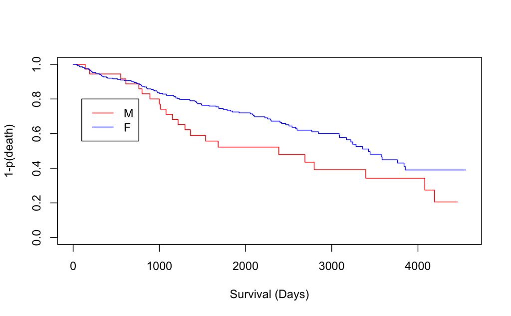

```r
library(survival)
days <- survivaldata$days
sex <- survivaldata$sex
d2d.ind <- as.numeric(!is.na(days) & !is.na(sex) & survivaldata$status==2) #days to death where days not na, and status is death
d2d.surv <- Surv(days, d2d.ind)
plot(survfit(d2d.surv~sex, data = survivaldata),
     col = c("red","blue"), xlab="Survival (Days)",
     ylab="1-p(death)")
legend(100,0.8, legend=c('M','F'), lwd=1, col=c('red','blue'))
```

```r
coxph(Surv(days, d2d.ind)~sex, data=survivaldata)
```

```
Call:
coxph(formula = Surv(days, d2d.ind) ~ sex, data = survivaldata)

       coef exp(coef) se(coef)      z      p
sex -0.4839    0.6164   0.2365 -2.046 0.0407

Likelihood ratio test=3.77  on 1 df, p=0.05214
n= 312, number of events= 125
```

**DISCUSS**

The status column in this data set is interesting: it is either censored (patient was still alive at the end of the study), censored due to transplant (the patient received a liver transplant so the event of death is unknown), or death. Based on this column, and that there is no remission/cured column, this survival data is considering death to be the event. In this comparison, we are looking at whether sex has a significant effect on the survival time of patients with Primary Biliary Cirrhosis.

First, I partitioned the columns of interest, survival days and patient sex, and saved them as objects. Logical operations were used to find the row/patient indices where both days and sex are not missing, and the status is death (2). This results in a logical vector indicating which patients experienced the event of interest. Applying this vector within the `Surv()` function creates a survival object for the analysis.

The `coxph()` function fits a Cox proportional hazards regression model to the survival object by patient sex, estimating the effect of sex on the hazard/risk of death. In this analysis, females are coded as 1 and males as 0 in the sex variable. This means that the model estimates the hazard of death for females relative to males. The model’s coefficient for sex describes how the risk changes for this comparison and the results show a negative coefficient for sex (-0.4839), and a hazard ratio less than 1 (0.6164), indicating that females have about 62% of the hazard of death occuring compared to males. The p-value for the sex variable is 0.0407, which is below the normal 0.05 threshold, suggesting that the effect of sex on survival is statistically significant. However, the likelihood ratio test for the overall model gives a p-value of 0.05214, just above the cutoff, indicating borderline significance for the model as a whole.

In summary, both the Kaplan-Meier plot and the Cox model suggest that females have a survival advantage over males in this data set, although the statistical evidence is not strong. Repeating this analysis with a larger sample size may help to clarify if the relationship is truely significant.